# Case Study - How can a wellness company play it smart?

Chang Jun Cheng

1/2/2022

## Data background

The data was collected on Kaggle for case study purpose, updated version of the original data sources by the maintainer *Kaggler* Möbius. Dataset date range from 4.12.2016 to 5.12.2016.

Below are the original dataset from https://zenodo.org/

Furberg, R., Brinton, J., Keating, M., & Ortiz, A. (2016). Crowd-sourced Fitbit datasets 03.12.2016-05.12.2016 [Data set]. Zenodo. https://doi.org/10.5281/zenodo.53894

### Install and load R packages

Install and load R packages, including `tidyverse`, `janitor`, `reshape` and `lubridate`

```r
install.packages("tidyverse")
install.packages("janitor")
install.packages("lubridate")
install.packages("reshape")
library("tidyverse")
library("janitor")
library("lubridate")
library("reshape")
```

### Load CSV files to R

Upload and load the CSV files that are stored in Big Query

**daily_activity_ver1** is the **original** version with 33 unique respondents

**daily_activity_ver2** is the **updated** version with 28 unique respondents by removing the rows with **sum of different levels of intensity minutes not equal to 1440 (60*24)**

For more information, click here [link](https://docs.google.com/spreadsheets/d/1YsUJBvP4Y285mPF_mBcTmMiZ435MLFQF_Tnt-ikPCeE/edit#gid=0)

```r
daily_activity_ver1 <- read.csv("dailyActivity_merged.csv")
daily_activity_ver2  <- read.csv("daily_data.csv")
daily_sleep <- read.csv("day_sleep.csv")
hourly_activity  <- read.csv("hourly_data.csv")
```

### Inspecting and exploring the key tables

```r
head(daily_activity_ver1)
```

```
##           Id ActivityDate TotalSteps TotalDistance TrackerDistance
## 1 1503960366    4/12/2016      13162          8.50            8.50
## 2 1503960366    4/13/2016      10735          6.97            6.97
## 3 1503960366    4/14/2016      10460          6.74            6.74
## 4 1503960366    4/15/2016       9762          6.28            6.28
## 5 1503960366    4/16/2016      12669          8.16            8.16
## 6 1503960366    4/17/2016       9705          6.48            6.48
##   LoggedActivitiesDistance VeryActiveDistance ModeratelyActiveDistance
## 1                        0               1.88                     0.55
## 2                        0               1.57                     0.69
## 3                        0               2.44                     0.40
## 4                        0               2.14                     1.26
## 5                        0               2.71                     0.41
## 6                        0               3.19                     0.78
##   LightActiveDistance SedentaryActiveDistance VeryActiveMinutes
## 1                6.06                       0                25
## 2                4.71                       0                21
## 3                3.91                       0                30
## 4                2.83                       0                29
## 5                5.04                       0                36
## 6                2.51                       0                38
##   FairlyActiveMinutes LightlyActiveMinutes SedentaryMinutes Calories
## 1                  13                  328              728     1985
## 2                  19                  217              776     1797
## 3                  11                  181             1218     1776
## 4                  34                  209              726     1745
## 5                  10                  221              773     1863
## 6                  20                  164              539     1728
```

```r
head(daily_sleep)
```

```
##           Id              SleepDay TotalSleepRecords TotalMinutesAsleep
## 1 1503960366 4/12/2016 12:00:00 AM                 1                327
## 2 1503960366 4/13/2016 12:00:00 AM                 2                384
## 3 1503960366 4/15/2016 12:00:00 AM                 1                412
## 4 1503960366 4/16/2016 12:00:00 AM                 2                340
## 5 1503960366 4/17/2016 12:00:00 AM                 1                700
## 6 1503960366 4/19/2016 12:00:00 AM                 1                304
##   TotalTimeInBed
## 1            346
## 2            407
## 3            442
## 4            367
## 5            712
## 6            320
```

```r
head(hourly_activity)
```

```
##           Id         ActivityHour StepTotal TotalIntensity AverageIntensity
## 1 8053475328 2016-04-15T22:00:00Z       770             41         0.683333
## 2 8053475328 2016-04-20T21:00:00Z       775             44         0.733333
## 3 8053475328 2016-05-05T14:00:00Z      3848             93         1.550000
## 4 8053475328 2016-04-25T18:00:00Z      1289             42         0.700000
## 5 8053475328 2016-04-30T15:00:00Z      3851             91         1.516667
## 6 8053475328 2016-04-19T15:00:00Z      1293             42         0.700000
##   Calories
## 1      169
## 2      174
## 3      348
## 4      184
## 5      369
## 6      187
```

### Understanding metadata of the key tables

```r
str(daily_activity_ver1)
```

```
## 'data.frame':    940 obs. of  15 variables:
##  $ Id                      : num  1.5e+09 1.5e+09 1.5e+09 1.5e+09 1.5e+09 ...
##  $ ActivityDate            : chr  "4/12/2016" "4/13/2016" "4/14/2016" "4/15/2016" ...
##  $ TotalSteps              : int  13162 10735 10460 9762 12669 9705 13019 15506 10544 9819 ...
##  $ TotalDistance           : num  8.5 6.97 6.74 6.28 8.16 ...
##  $ TrackerDistance         : num  8.5 6.97 6.74 6.28 8.16 ...
##  $ LoggedActivitiesDistance: num  0 0 0 0 0 0 0 0 0 0 ...
##  $ VeryActiveDistance      : num  1.88 1.57 2.44 2.14 2.71 ...
##  $ ModeratelyActiveDistance: num  0.55 0.69 0.4 1.26 0.41 ...
##  $ LightActiveDistance     : num  6.06 4.71 3.91 2.83 5.04 ...
##  $ SedentaryActiveDistance : num  0 0 0 0 0 0 0 0 0 0 ...
##  $ VeryActiveMinutes       : int  25 21 30 29 36 38 42 50 28 19 ...
##  $ FairlyActiveMinutes     : int  13 19 11 34 10 20 16 31 12 8 ...
##  $ LightlyActiveMinutes    : int  328 217 181 209 221 164 233 264 205 211 ...
##  $ SedentaryMinutes        : int  728 776 1218 726 773 539 1149 775 818 838 ...
##  $ Calories                : int  1985 1797 1776 1745 1863 1728 1921 2035 1786 1775 ...
```

```r
str(daily_activity_ver2)
```

```
## 'data.frame':    478 obs. of  15 variables:
##  $ Id                      : num  1.62e+09 1.64e+09 1.64e+09 1.64e+09 1.64e+09 ...
##  $ ActivityDate            : chr  "2016-05-01" "2016-04-14" "2016-04-19" "2016-04-28" ...
##  $ TotalSteps              : int  36019 11037 11256 9405 12850 15112 13379 14687 13175 10771 ...
##  $ TotalDistance           : num  28.03 8.02 8.18 6.84 9.34 ...
##  $ TrackerDistance         : num  28.03 8.02 8.18 6.84 9.34 ...
##  $ LoggedActivitiesDistance: num  0 0 0 0 0 0 0 0 0 0 ...
##  $ VeryActiveDistance      : num  21.92 0.36 0.36 0.2 0.72 ...
##  $ ModeratelyActiveDistance: num  4.19 2.56 2.53 2.32 4.09 ...
##  $ LightActiveDistance     : num  1.91 5.1 5.3 4.31 4.54 ...
##  $ SedentaryActiveDistance : num  0.02 0 0 0 0 ...
##  $ VeryActiveMinutes       : int  186 5 5 3 10 48 35 8 33 70 ...
##  $ FairlyActiveMinutes     : int  63 58 58 53 94 63 47 122 45 113 ...
##  $ LightlyActiveMinutes    : int  171 252 278 227 221 276 297 151 262 178 ...
##  $ SedentaryMinutes        : int  1020 1125 1099 1157 1115 1053 1061 1159 1100 1079 ...
##  $ Calories                : int  2690 3226 3300 3108 3324 2897 2709 1667 3425 3727 ...
```

```r
str(daily_sleep)
```

```
## 'data.frame':    413 obs. of  5 variables:
##  $ Id                : num  1.5e+09 1.5e+09 1.5e+09 1.5e+09 1.5e+09 ...
##  $ SleepDay          : chr  "4/12/2016 12:00:00 AM" "4/13/2016 12:00:00 AM" "4/15/2016 12:00:00 AM" "4/16/2016 12:00:00 AM" ...
##  $ TotalSleepRecords : int  1 2 1 2 1 1 1 1 1 1 ...
##  $ TotalMinutesAsleep: int  327 384 412 340 700 304 360 325 361 430 ...
##  $ TotalTimeInBed    : int  346 407 442 367 712 320 377 364 384 449 ...
```

```r
str(hourly_activity)
```

```
## 'data.frame':    22099 obs. of  6 variables:
##  $ Id              : num  8.05e+09 8.05e+09 8.05e+09 8.05e+09 8.05e+09 ...
##  $ ActivityHour    : chr  "2016-04-15T22:00:00Z" "2016-04-20T21:00:00Z" "2016-05-05T14:00:00Z" "2016-04-25T18:00:00Z" ...
##  $ StepTotal       : int  770 775 3848 1289 3851 1293 1042 2835 3604 3349 ...
##  $ TotalIntensity  : int  41 44 93 42 91 42 36 83 86 83 ...
##  $ AverageIntensity: num  0.683 0.733 1.55 0.7 1.517 ...
##  $ Calories        : int  169 174 348 184 369 187 162 281 343 313 ...
```

### Identify unique respondents for each dataset

```r
n_distinct(daily_activity_ver1$Id)
```

```
## [1] 33
```

```r
n_distinct(daily_activity_ver2$Id)
```

```
## [1] 28
```

```r
n_distinct(daily_sleep$Id)
```

```
## [1] 24
```

```r
n_distinct(hourly_activity$Id)
```

```
## [1] 33
```

### Data Cleaning

#### Data cleaning - clean names for all variables

In this part, do ensure that `janitor` packages is installed and loaded.

```r
daily_activity_ver1 <- daily_activity_ver1 %>% clean_names()
daily_activity_ver2 <- daily_activity_ver2 %>%  clean_names()
daily_sleep <- daily_sleep %>%  clean_names()
hourly_activity <- hourly_activity %>%  clean_names()
```

#### Data cleaning - rename all date related variable to date

Rename the date related variable to date for consistency and later part of analysis.

```r
daily_activity_ver1 <- dplyr::rename(daily_activity_ver1, date = activity_date)
daily_activity_ver2 <- dplyr::rename(daily_activity_ver2, date = activity_date)
daily_sleep <-  dplyr::rename(daily_sleep, date = sleep_day)
hourly_activity <-  dplyr::rename(hourly_activity, date = activity_hour)
```

#### Data cleaning - change all date related variable from chr to date data type

Change data type for date variable

```r
daily_activity_ver1$date <- as.Date(daily_activity_ver1$date, "%m/%d/%Y")
str(daily_activity_ver1)
```

```
## 'data.frame':    940 obs. of  15 variables:
##  $ id                        : num  1.5e+09 1.5e+09 1.5e+09 1.5e+09 1.5e+09 ...
##  $ date                      : Date, format: "2016-04-12" "2016-04-13" ...
##  $ total_steps               : int  13162 10735 10460 9762 12669 9705 13019 15506 10544 9819 ...
##  $ total_distance            : num  8.5 6.97 6.74 6.28 8.16 ...
##  $ tracker_distance          : num  8.5 6.97 6.74 6.28 8.16 ...
##  $ logged_activities_distance: num  0 0 0 0 0 0 0 0 0 0 ...
##  $ very_active_distance      : num  1.88 1.57 2.44 2.14 2.71 ...
##  $ moderately_active_distance: num  0.55 0.69 0.4 1.26 0.41 ...
##  $ light_active_distance     : num  6.06 4.71 3.91 2.83 5.04 ...
##  $ sedentary_active_distance : num  0 0 0 0 0 0 0 0 0 0 ...
##  $ very_active_minutes       : int  25 21 30 29 36 38 42 50 28 19 ...
##  $ fairly_active_minutes     : int  13 19 11 34 10 20 16 31 12 8 ...
##  $ lightly_active_minutes    : int  328 217 181 209 221 164 233 264 205 211 ...
##  $ sedentary_minutes         : int  728 776 1218 726 773 539 1149 775 818 838 ...
##  $ calories                  : int  1985 1797 1776 1745 1863 1728 1921 2035 1786 1775 ...
```

```r
daily_activity_ver2$date <- as.Date(daily_activity_ver2$date, "%m/%d/%Y")
daily_sleep$date <- as.Date(daily_sleep$date, "%m/%d/%Y")
hourly_activity$date <- as.POSIXct(hourly_activity$date, format="%Y-%m-%dT%H:%M")
str(hourly_activity)
```

```
## 'data.frame':    22099 obs. of  6 variables:
##  $ id               : num  8.05e+09 8.05e+09 8.05e+09 8.05e+09 8.05e+09 ...
##  $ date             : POSIXct, format: "2016-04-15 22:00:00" "2016-04-20 21:00:00" ...
##  $ step_total       : int  770 775 3848 1289 3851 1293 1042 2835 3604 3349 ...
##  $ total_intensity  : int  41 44 93 42 91 42 36 83 86 83 ...
##  $ average_intensity: num  0.683 0.733 1.55 0.7 1.517 ...
##  $ calories         : int  169 174 348 184 369 187 162 281 343 313 ...
```

### Identify the maximum and minimum date

```r
max_date = max(daily_activity_ver2$date)
min_date = min(daily_activity_ver2$date)
```

### Analyze and visualize data (minutes spent on every intensity level in a day)

Deep dive into **daily_activity_ver2** to explore and discover relationship between the variables. * discover the average portion of intensity level minutes in a day * unpivot the 4 columns (wide format to long format)

install `reshape` packages to `melt` (unpivot the columns)

```r
daily_activity_ver2_1 <- daily_activity_ver2 %>%
  select(id, very_active_minutes, fairly_active_minutes, lightly_active_minutes, sedentary_minutes)

melted_daily_activity <- melt(daily_activity_ver2_1, id = c("id"),
                              variable_name = c('intensity_level'))

melted_daily_activity_2 <- melted_daily_activity %>% select(intensity_level, value) %>%
  group_by(intensity_level) %>%
  summarize(mean_minutes = mean(value))
```

- visualize data (observe the weight of each intensity level for a day)

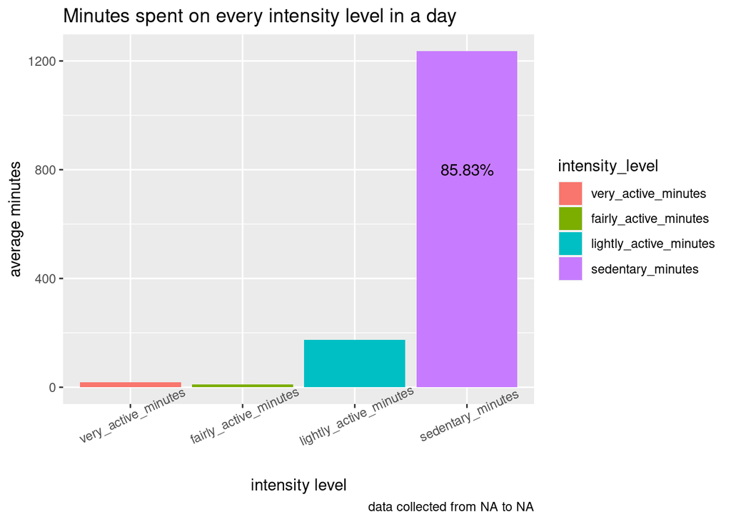

```r
portion_sedentary = round(melted_daily_activity_2$mean_minutes[4]/1440*100,2)

p1 <- melted_daily_activity_2 %>% ggplot(mapping = aes(x=intensity_level, y=mean_minutes, fill=intensity_level))+geom_col()

p1 + labs(title = "Minutes spent on every intensity level in a day", x = "intensity level", y = "average minutes",
          caption=paste0("data collected from ", min_date, " to ",  max_date))+
  theme(axis.text.x = element_text(angle = 25) )+
  annotate(geom = "text", x = "sedentary_minutes", y = 800, label =paste0(portion_sedentary, "%"))
```

### Inferencial statistics - hypothesis testing (t-test)

```r
df1 <- melted_daily_activity %>%
  select(intensity_level, value) %>%
  filter(intensity_level == "very_active_minutes" |
           intensity_level == "sedentary_minutes")

t.test(data = df1, value ~ intensity_level)
```

```
##
##  Welch Two Sample t-test
##
## data:  value by intensity_level
## t = -190.32, df = 524.91, p-value < 2.2e-16
## alternative hypothesis: true difference in means between group very_active_minutes and group sedentary_minutes is not equal to 0
## 95 percent confidence interval:
##  -1229.431 -1204.310
## sample estimates:
## mean in group very_active_minutes   mean in group sedentary_minutes
##                          19.08159                        1235.95188
```

Conclusion: On average, respondent spent **85.83%** of a day in sedentary behavior.

### Analyze and visualize data 2 (relationship between total steps, average intensities and calories)

Total Steps Taken vs Average intensity

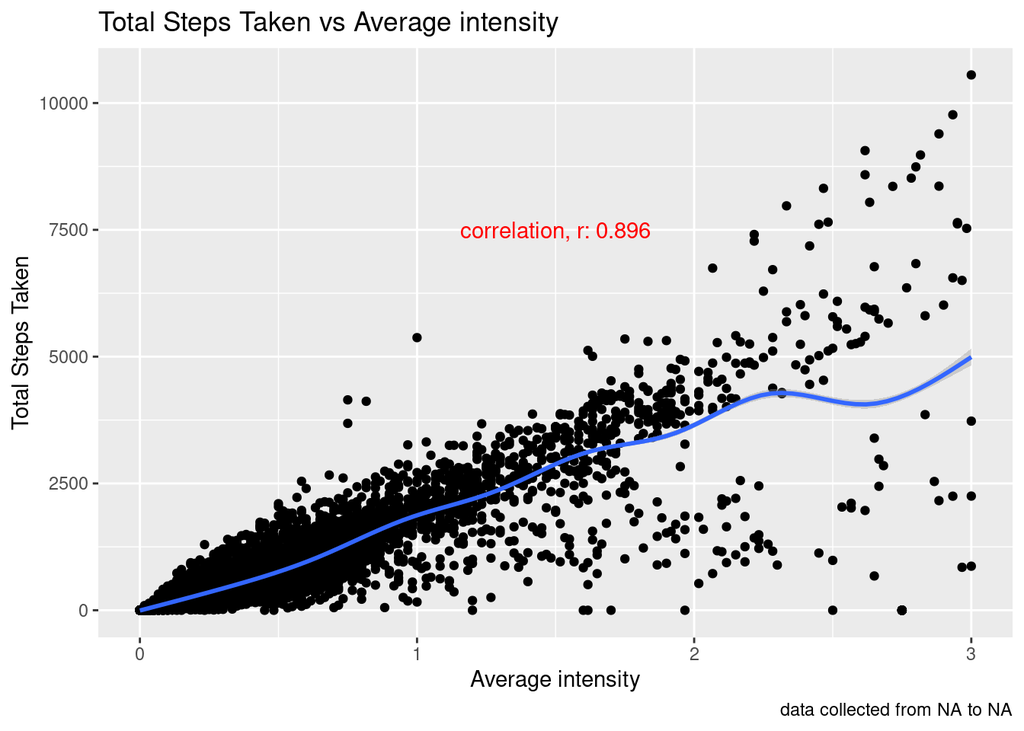

```r
corr1 <- round(cor(hourly_activity$average_intensity, hourly_activity$step_total),4)

p2 <- hourly_activity %>%  ggplot(aes(x=average_intensity, y=step_total))+
  geom_point()+geom_smooth()


p2 + labs(title = "Total Steps Taken vs Average intensity", x = "Average intensity", y = "Total Steps Taken",
          caption=paste0("data collected from ", min_date, " to ",  max_date))+
  annotate(geom = "text", x = 1.5, y = 7500, label =paste0("correlation, r: ", corr1), color = "red")
```

Calories burned vs Average intensity

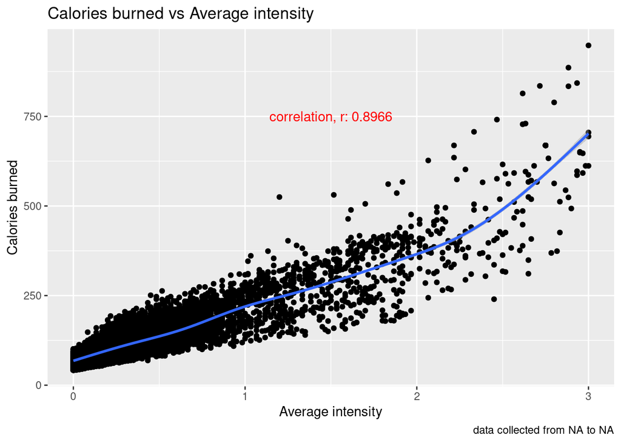

```r
corr2 <- round(cor(hourly_activity$average_intensity, hourly_activity$calories),4)

p3 <- hourly_activity %>%  ggplot(aes(x=average_intensity, y=calories))+
  geom_point()+geom_smooth()


p3 + labs(title = "Calories burned vs Average intensity", x = "Average intensity", y = "Calories burned",
          caption=paste0("data collected from ", min_date, " to ",  max_date))+
  annotate(geom = "text", x = 1.5, y = 750, label =paste0("correlation, r: ", corr2), color = "red")
```

Calories burned vs Total steps taken

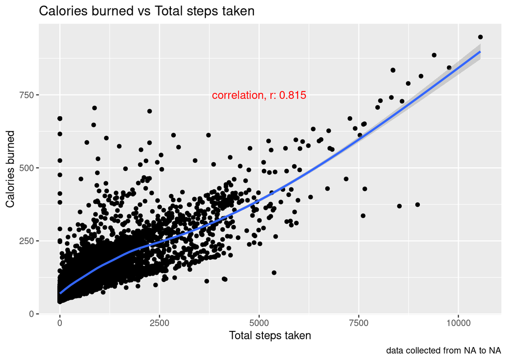

```r
corr3 <- round(cor(hourly_activity$step_total, hourly_activity$calories),4)

p4 <- hourly_activity %>%  ggplot(aes(x=step_total, y=calories))+
  geom_point()+geom_smooth()


p4 + labs(title = "Calories burned vs Total steps taken", x = "Total steps taken", y = "Calories burned",
          caption=paste0("data collected from ", min_date, " to ",  max_date))+
  annotate(geom = "text", x = 5000, y = 750, label =paste0("correlation, r: ", corr3), color = "red")
```

Calories burned vs Total distance

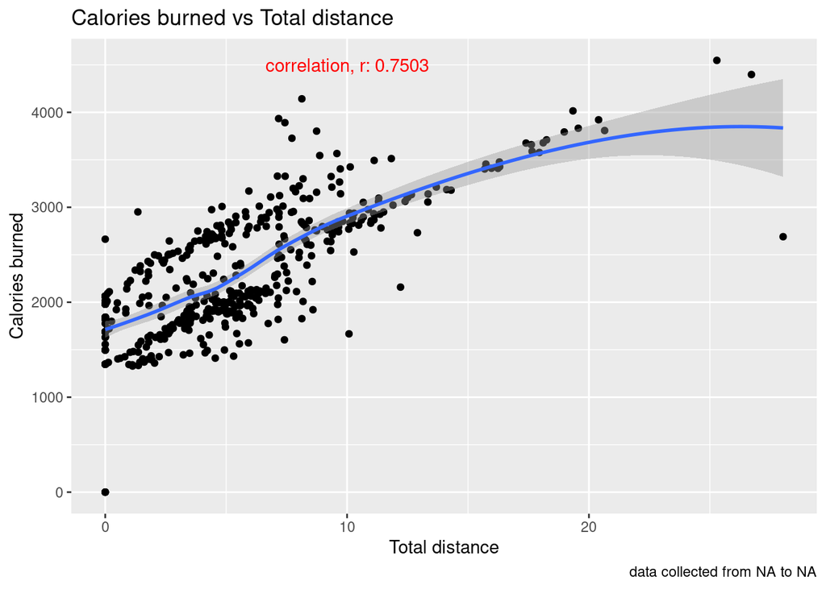

```r
corr4 <- round(cor(daily_activity_ver2$total_distance,daily_activity_ver2$calories),4)

p5 <- daily_activity_ver2 %>% ggplot(aes(x=total_distance, y=calories))+geom_point()+geom_smooth()

p5 + labs(title = "Calories burned vs Total distance", x = "Total distance", y = "Calories burned",
          caption=paste0("data collected from ", min_date, " to ",  max_date))+
  annotate(geom = "text", x = 10, y = 4500, label =paste0("correlation, r: ", corr4), color = "red")
```

**Conclusion: the more distance go for a day, the more calories burned in a day.**

## Findings 1

**Findings: With high intensity, high total steps taken and more distance taken, more calories will be burned as well**

### Analyze and visualize data 3 (explore relationship between intensity, total distance and sleep)

- `inner_join` the daily sleep table and daily activity ver 1

Total distance vs Sedentary minutes

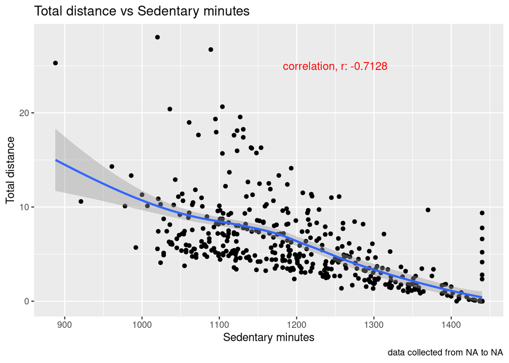

```r
corr5 <- round(cor(daily_activity_ver2$total_distance,daily_activity_ver2$sedentary_minutes),4)

p6 <- daily_activity_ver2 %>% ggplot(aes(x=sedentary_minutes, y=total_distance))+geom_point()+geom_smooth()

p6 + labs(title = "Total distance vs Sedentary minutes", x = "Sedentary minutes", y = "Total distance",
          caption=paste0("data collected from ", min_date, " to ",  max_date))+
  annotate(geom = "text", x = 1250, y = 25, label =paste0("correlation, r: ", corr5), color = "red")
```

**Conclusion: the lesser minutes spent on sedentary behavior, the more the distance taken.**

Sedentary minutes vs Total minutes asleep

```r
combined_data <-inner_join(daily_sleep, daily_activity_ver1, by=c("id", "date"))
```

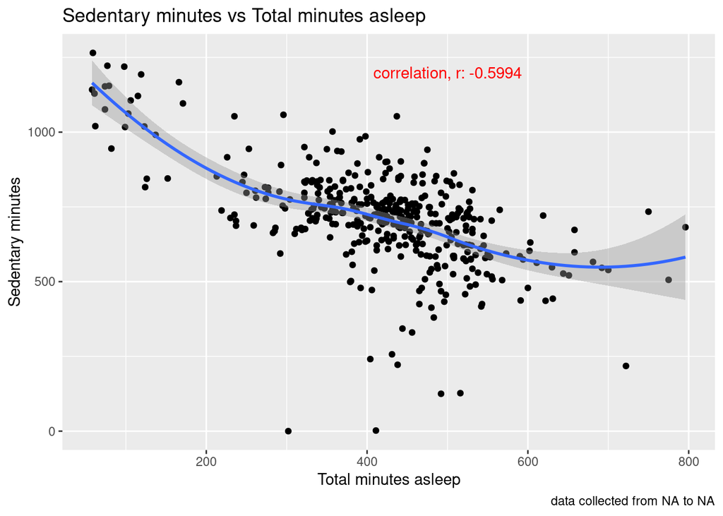

```r
corr6<- round(cor(combined_data$total_minutes_asleep,combined_data$sedentary_minutes),4)

p7 <- combined_data %>% ggplot(aes(x=total_minutes_asleep,y=sedentary_minutes))+geom_point()+geom_smooth()

p7 + labs(title = "Sedentary minutes vs Total minutes asleep", x = "Total minutes asleep", y = "Sedentary minutes",
          caption=paste0("data collected from ", min_date, " to ",  max_date))+
  annotate(geom = "text", x = 500, y = 1200, label =paste0("correlation, r: ", corr6), color = "red")
```

**Conclusions: The more minutes a people fall asleep, the lesser minutes spent on sedentary behavior**

## Findings 2

### Analyze and visualize data 4 (explore sleeping habits)

[figure not shown]

```r
corr7 <- round(cor(daily_sleep$total_time_in_bed, daily_sleep$total_minutes_asleep),4)

p8 <- daily_sleep %>% ggplot(aes(x=total_time_in_bed, y=total_minutes_asleep))+geom_point()+geom_smooth()

p8 + labs(title = "Total minutes asleep vs Total time in bed", x = "Total time in bed", y = "Total minutes asleep",
          caption=paste0("data collected from ", min_date, " to ",  max_date))+
  annotate(geom = "text", x = 500, y = 760, label =paste0("correlation: ", corr5), color = "red")
```

**Findings: the more time on bed, the more minutes fall asleep.**

### Linear regression (y = Sedentary minutes, x = total minutes asleep)

```r
summary(lm(data = combined_data, sedentary_minutes ~ total_minutes_asleep))
```

```
##
## Call:
## lm(formula = sedentary_minutes ~ total_minutes_asleep, data = combined_data)
##
## Residuals:
##     Min      1Q  Median      3Q     Max
## -810.91  -57.61    7.55   71.53  355.57
##
## Coefficients:
##                        Estimate Std. Error t value Pr(>|t|)
## (Intercept)          1064.75015   24.12981   44.13   <2e-16 ***
## total_minutes_asleep   -0.84054    0.05537  -15.18   <2e-16 ***
## ---
## Signif. codes:  0 '***' 0.001 '**' 0.01 '*' 0.05 '.' 0.1 ' ' 1
##
## Residual standard error: 133 on 411 degrees of freedom
## Multiple R-squared:  0.3593, Adjusted R-squared:  0.3577
## F-statistic: 230.5 on 1 and 411 DF,  p-value: < 2.2e-16
```

### High-level recommendation:

- **Add in new features to current smart device to track user’s sleeping habits.**
- **Design a dashboard specifying the impact of good quality sleeping, eg. how it affects your daily life using data.**

### Next Analysis:

- **Identify more on user’s sleeping habits.**
- **Determine the 3 most important factors for a good quality sleeping.**